# Análise de Gastos de Deputados: Suas Perguntas

Diogo Florêncio

02 de novembro de 2017

```r
library(tidyverse)
library(ggplot2)
options(scipen = 4)
ceap <- read_csv("../dados/dadosCEAP.csv") %>%
  filter(nomeParlamentar != "NA")
```

Por meio dos dados coletados da Câmara dos Deputados iremos determinar características interessantes sobre o uso da CEAP, durante o período de outubro de 2014 à novembro de 2017.

A CEAP (cota para o exercício da atividade parlamentar) é uma cota única mensal destinada a custear os gastos dos deputados exclusivamente vinculados ao exercício da atividade parlamentar. Exemplos de despesa desse tipo são: passagens aéreas, telefonia, serviços postais, manutenção de escritórios de apoio à atividade parlamentar, assinatura de publicações, fornecimento de alimentação ao parlamentar, hospedagem, outras despesas com locomoção, contemplando locação ou fretamento de aeronaves, veículos automotores e embarcações, serviços de táxi, pedágio e estacionamento e passagens terrestres. Os dados desta análise estão disponíveis aqui.

# Quais deputados mais viajam?

Para mensurar quanto um deputado viaja considerei a quantidade de documentos fiscais referentes à viagens aéreas. Não foram considerados documentos estornados.

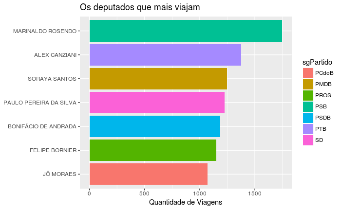

```r
viagens_parlamentar <- ceap %>%
  filter(grepl("AÉRE", tipoDespesa, ignore.case = TRUE)) %>%
  filter(valorLíquido > 0) %>%
  group_by(idCadastro, nomeParlamentar, sgPartido) %>%
  summarise(viagens = as.integer(n())) %>% ungroup()
viagens_parlamentar %>%
  top_n(viagens_parlamentar$viagens, n = 7) %>%
  ggplot(aes(x = reorder(nomeParlamentar, viagens), y = viagens, fill = sgPartido)) +
  geom_bar(stat="identity") +
  theme(axis.title.y=element_blank()) +
  coord_flip() +
  ylab("Quantidade de Viagens") +
  ggtitle("Os deputados que mais viajam")
```

O gráfico exibe os 7 deputados que mais viajam, a legenda relaciona deputado e partido.

# Quais partidos mais gastam com divulgação?

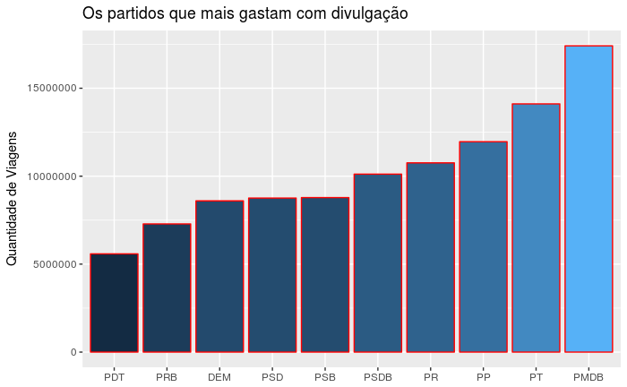

```r
divulgacao <- ceap %>%
  filter(grepl("DIVULGAÇÃO",tipoDespesa, ignore.case = TRUE)) %>%
  group_by(sgPartido) %>%
  summarise(valor_gasto = sum(valorLíquido))
divulgacao %>%
  top_n(divulgacao$valor_gasto, n = 10) %>%
  ggplot(aes(x = reorder(sgPartido, valor_gasto), y = valor_gasto, fill = valor_gasto)) +
  geom_bar(stat="identity", color="red") +
  theme(axis.title.x=element_blank(), legend.position="none") +
  ylab("Quantidade de Viagens") +
  ggtitle("Os partidos que mais gastam com divulgação")
```

O gráfico mostra os 10 partidos que mais gastam com *Divulgação da Atividade Parlamentar*.

# Existe correlação entre a quantidade de viagens de um partido e seus gastos com divulgação?

Para determinar se existe correlação entre a quantidade de viagens e os gastos com divulgação de um partido vamos olhar a disposição dos dados. O gráfico relaciona quanto os deputados de um partido viajam e quanto gastam com *Divulgação da Atividade Parlamentar*.

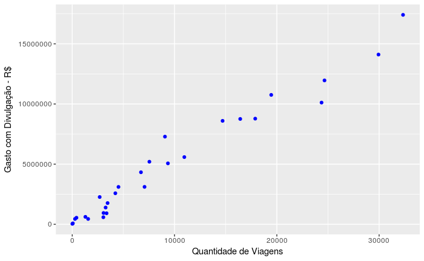

```r
viagens_partidos <- ceap %>%
  filter(grepl("AÉRE", tipoDespesa, ignore.case = TRUE)) %>%
  filter(valorLíquido > 0) %>%
  group_by(sgPartido) %>%
  summarise(viagens = n())
partidos <- merge(viagens_partidos,divulgacao)
partidos %>%
    ggplot(aes(x = viagens, y = valor_gasto)) +
    geom_point(color = "blue") +
    xlab("Quantidade de Viagens") + ylab("Gasto com Divulgação - R$")
```

```r
cor(partidos$viagens, partidos$valor_gasto)
```

```
[1] 0.9810439
```

É possível perceber uma clara correlação linear positiva entre as variáveis. A correlação linear é de 0.9810439, ou seja, quanto mais os deputados de um partido viajam mais o partido como um todo gasta com *Divulgação da Atividade Parlamentar*.